# Matt-Hat Jerky 2021 YTD (Jan-Oct) Sales Analysis

# Executive Summary

# Data Description

[figure not shown]

## Matt-Hat Jerky Overview

Their website is https://www.matthatjerky.com.

## Data Set Overview

Our data set includes sales data from January to October 2021 grouped by month, sales channel, location, customer type, product, and product type. Each record contains the number of orders, gross sales, discounts, returns, net sales, shipping, taxes, total sales, total tips, and average order value.

The data set contains:

28071 records  
18 variables

1. Month = month (datatype: character) - Month starts at January 2021 (i.e., 2021-01) and end in October 2021 (i.e., 2021-10). This field signifies the month in which a purchase occurs.
2. Sales Channel = api_client_title (datatype: character) -
3. Shipped to City = shipping_city (datatype: character) -
4. Shipped to Region = shipping_region (datatype: character) -
5. Shipping to Country = shipping_country (datatype: character)
6. First/Return Customer Type = customer_type (datatype: character)
7. Matt-Hat Jerky Product Name = product_title (datatype: character)
8. Matt-Hat Jerky Product Type = product_type (datatype: character)
9. Number of Orders = orders (datatype: integer)
10. Gross Sales = gross_sales (datatype: number)
11. Discounts = discounts (datatype: number)
12. Returns = returns (datatype: number)
13. Net Sales = net_sales (datatype: number) - Net sales are the a function of when sales discounts and returns are subtracted from gross sales.

$$Net Sales = Gross Sales - Discounts - Returns$$

14. Shipping = shipping (datatype: number)
15. Taxes = taxes (datatype: number)
16. Total Sales = total_sales (datatype: number)

$$Total Sales = Net Sales + Shipping + Taxes$$

17. Total Tips = total_tips (datatype: number) - Total tips include one-time donations from customers to Matt-Hat Jerky as a thank you for services. The fields works similar to tipping at a restaurant.
18. Average Order Value = average_order_value (datatype: number)

## Exploratory Data Analysis (EDA)

```r
# Read the data into RStudio & assign it to the 'sales' variable.
sales <- read.csv('sales_2021_YTD.csv')

# Take an initial look at the data frame fields, records, data types, etc. to see if anything seems off.
skimr::skim(sales)
```

Data summary

| Name | sales |
| --- | --- |
| Number of rows | 28071 |
| Number of columns | 18 |
| _______________________ |  |
| Column type frequency: |  |
| character | 8 |
| numeric | 10 |
| ________________________ |  |
| Group variables | None |

**Variable type: character**

| skim_variable | n_missing | complete_rate | min | max | empty | n_unique | whitespace |
| --- | --- | --- | --- | --- | --- | --- | --- |
| month | 0 | 1 | 7 | 7 | 0 | 10 | 0 |
| api_client_title | 0 | 1 | 0 | 20 | 1 | 6 | 0 |
| shipping_city | 0 | 1 | 0 | 25 | 21 | 3155 | 0 |
| shipping_region | 0 | 1 | 0 | 20 | 23 | 60 | 0 |
| shipping_country | 0 | 1 | 0 | 14 | 21 | 5 | 0 |
| customer_type | 0 | 1 | 0 | 10 | 1 | 3 | 0 |
| product_title | 0 | 1 | 0 | 79 | 8222 | 60 | 0 |
| product_type | 0 | 1 | 0 | 16 | 20833 | 8 | 0 |

**Variable type: numeric**

| skim_variable | n_missing | complete_rate | mean | sd | p0 | p25 | p50 | p75 | p100 | hist |
| --- | --- | --- | --- | --- | --- | --- | --- | --- | --- | --- |
| orders | 0 | 1 | 0.75 | 0.58 | 0.00 | 0.00 | 1.00 | 1.00 | 8.00 | ▇▁▁▁▁ |
| gross_sales | 0 | 1 | 21.20 | 33.18 | 0.00 | 0.00 | 8.99 | 26.97 | 1573.25 | ▇▁▁▁▁ |
| discounts | 0 | 1 | -1.82 | 5.84 | -393.31 | -0.45 | 0.00 | 0.00 | 0.00 | ▁▁▁▁▇ |
| returns | 0 | 1 | -0.27 | 4.73 | -421.56 | 0.00 | 0.00 | 0.00 | 29.08 | ▁▁▁▁▇ |
| net_sales | 0 | 1 | 19.10 | 29.27 | -421.56 | 0.00 | 8.99 | 23.98 | 1179.94 | ▁▇▁▁▁ |
| shipping | 0 | 1 | 1.45 | 3.95 | -13.16 | 0.00 | 0.00 | 0.00 | 95.75 | ▇▁▁▁▁ |
| taxes | 0 | 1 | 0.08 | 0.67 | -0.54 | 0.00 | 0.00 | 0.00 | 70.80 | ▇▁▁▁▁ |
| total_sales | 0 | 1 | 20.63 | 28.79 | -421.56 | 6.66 | 9.53 | 24.99 | 1250.74 | ▁▇▁▁▁ |
| total_tips | 0 | 1 | 0.06 | 0.73 | 0.00 | 0.00 | 0.00 | 0.00 | 27.87 | ▇▁▁▁▁ |
| average_order_value | 0 | 1 | 17.78 | 25.03 | 0.00 | 0.00 | 8.99 | 22.77 | 1250.74 | ▇▁▁▁▁ |

```r
summary(sales)
```

```
##     month           api_client_title   shipping_city      shipping_region
##  Length:28071       Length:28071       Length:28071       Length:28071
##  Class :character   Class :character   Class :character   Class :character
##  Mode  :character   Mode  :character   Mode  :character   Mode  :character
##
##
##
##  shipping_country   customer_type      product_title      product_type
##  Length:28071       Length:28071       Length:28071       Length:28071
##  Class :character   Class :character   Class :character   Class :character
##  Mode  :character   Mode  :character   Mode  :character   Mode  :character
##
##
##
##      orders        gross_sales        discounts           returns
##  Min.   :0.0000   Min.   :   0.00   Min.   :-393.310   Min.   :-421.560
##  1st Qu.:0.0000   1st Qu.:   0.00   1st Qu.:  -0.450   1st Qu.:   0.000
##  Median :1.0000   Median :   8.99   Median :   0.000   Median :   0.000
##  Mean   :0.7545   Mean   :  21.20   Mean   :  -1.818   Mean   :  -0.274
##  3rd Qu.:1.0000   3rd Qu.:  26.97   3rd Qu.:   0.000   3rd Qu.:   0.000
##  Max.   :8.0000   Max.   :1573.25   Max.   :   0.000   Max.   :  29.080
##    net_sales          shipping          taxes           total_sales
##  Min.   :-421.56   Min.   :-13.16   Min.   :-0.54000   Min.   :-421.56
##  1st Qu.:   0.00   1st Qu.:  0.00   1st Qu.: 0.00000   1st Qu.:   6.66
##  Median :   8.99   Median :  0.00   Median : 0.00000   Median :   9.53
##  Mean   :  19.10   Mean   :  1.45   Mean   : 0.07793   Mean   :  20.63
##  3rd Qu.:  23.98   3rd Qu.:  0.00   3rd Qu.: 0.00000   3rd Qu.:  24.99
##  Max.   :1179.94   Max.   : 95.75   Max.   :70.80000   Max.   :1250.74
##    total_tips       average_order_value
##  Min.   : 0.00000   Min.   :   0.00
##  1st Qu.: 0.00000   1st Qu.:   0.00
##  Median : 0.00000   Median :   8.99
##  Mean   : 0.06322   Mean   :  17.78
##  3rd Qu.: 0.00000   3rd Qu.:  22.77
##  Max.   :27.87000   Max.   :1250.74
```

```r
head(sales, 20)
```

```
##      month api_client_title shipping_city shipping_region shipping_country
## 1  2021-01
## 2  2021-02     Online Store Jefferson Twp    Pennsylvania    United States
## 3  2021-02     Online Store Jefferson Twp    Pennsylvania    United States
## 4  2021-02     Online Store Jefferson Twp    Pennsylvania    United States
## 5  2021-02     Online Store Jefferson Twp    Pennsylvania    United States
## 6  2021-03     Online Store       Dubuque            Iowa    United States
## 7  2021-03     Online Store    Sacramento      California    United States
## 8  2021-03     Online Store   West Covina      California    United States
## 9  2021-03     Online Store    Sacramento      California    United States
## 10 2021-03     Online Store       Methuen   Massachusetts    United States
## 11 2021-03     Online Store    Sacramento      California    United States
## 12 2021-03     Online Store       Methuen   Massachusetts    United States
## 13 2021-03     Online Store    Sacramento      California    United States
## 14 2021-03     Online Store Franklin Park        Illinois    United States
```

[output cut: 69 more lines]

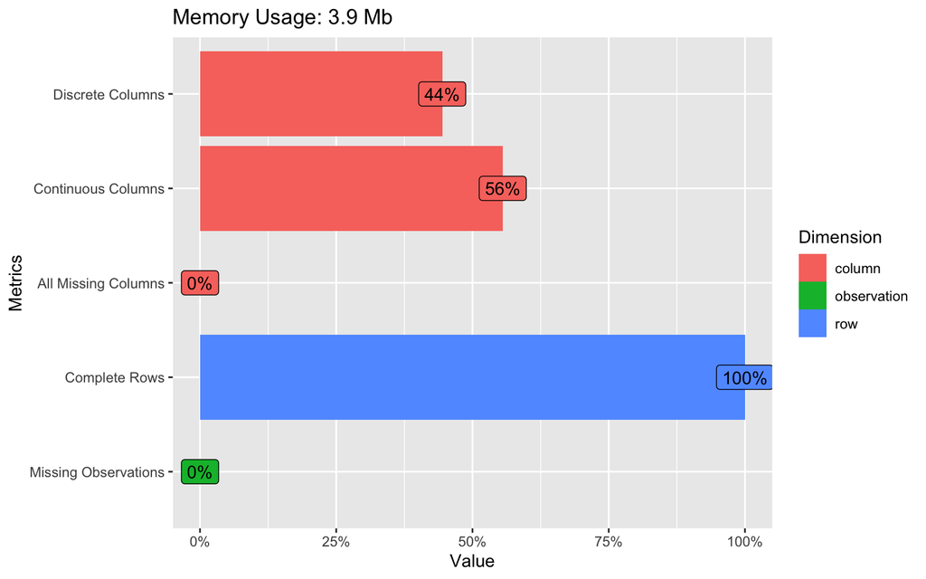

```r
DataExplorer::plot_intro(sales)
```

```
## 3 columns ignored with more than 50 categories.
## shipping_city: 3155 categories
## shipping_region: 60 categories
## product_title: 60 categories
```

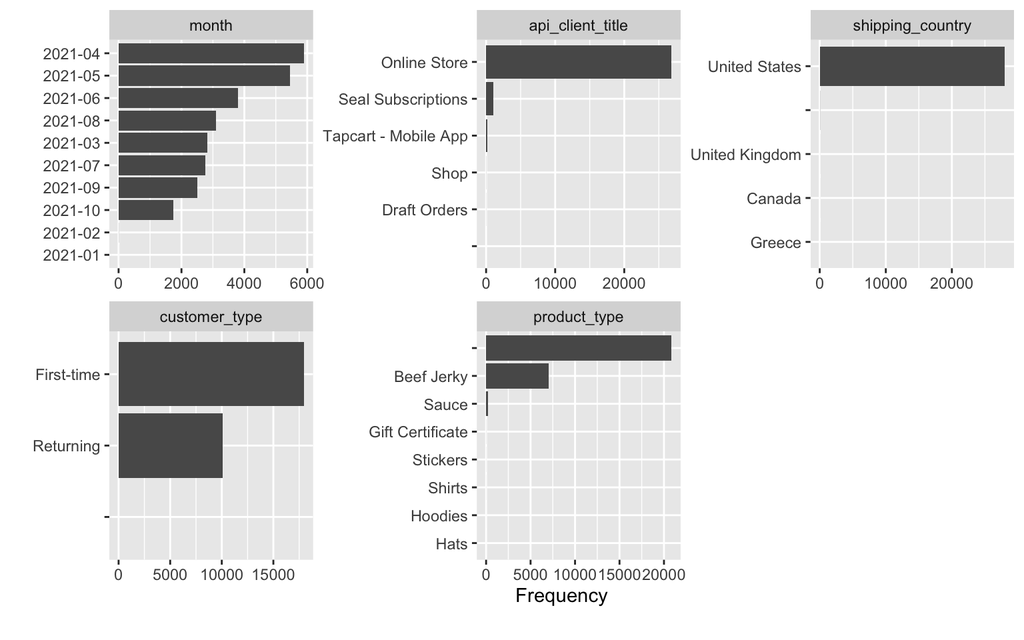

```r
DataExplorer::plot_bar(sales)
```

There seems to some missing values in the product title and product type fields just by viewing the first 20 records of the data set.

```r
uniqueTime <- unique(sales[1], incomparables = FALSE)
uniqueSalesChannel <- unique(sales[2], incomparables = FALSE)
uniqueCity <- unique(sales[3], incomparables = FALSE)
uniqueRegion <- unique(sales[4], incomparables = FALSE)
uniqueCountry <- unique(sales[5], incomparables = FALSE)
uniqueCustomerType <- unique(sales[6], incomparables = FALSE)
uniqueProductTitle <- unique(sales[7], incomparables = FALSE)
uniqueProductType <- unique(sales[8], incomparables = FALSE)

uniqueFields <- c(uniqueTime, uniqueSalesChannel, uniqueCity, uniqueRegion, uniqueCountry, uniqueCustomerType, uniqueProductTitle, uniqueProductType)

uniqueFields
```

```
## $month
##  [1] "2021-01" "2021-02" "2021-03" "2021-04" "2021-05" "2021-06" "2021-07"
##  [8] "2021-08" "2021-09" "2021-10"
##
## $api_client_title
## [1] ""                     "Online Store"         "Seal Subscriptions"
## [4] "Shop"                 "Tapcart - Mobile App" "Draft Orders"
##
## $shipping_city
##    [1] ""                          "Jefferson Twp"
##    [3] "Dubuque"                   "Sacramento"
##    [5] "West Covina"               "Methuen"
##    [7] "Franklin Park"             "Cromwell"
##    [9] "Odessa"                    "Stanhope"
##   [11] "Farmingdale"               "Ashton"
```

[output cut: 1667 more lines]

```r
cleanSales <- sales %>%
              select(c('month','api_client_title','shipping_region','customer_type','product_title','orders','gross_sales','discounts','returns','net_sales','shipping','taxes','total_sales','total_tips','average_order_value'))
```

# Research Questions

1. Which sales channel, location, and product combination are most likely to produce high lifetime value (LTV) customers? High LTV customers are those we high order counts, and high net sales (minimal discounts & returns).
2. Which sales channel, location, and product combination are likely to produce returning customers?
3. Which sales channel, location, and product combination produce the highest average order value (AOV)? AOV is used in determining how much marketing dollars are worth spending.

```r
salesWithDummies <- dummy_cols(sales, select_columns = c('api_client_title', 'shipping_region', 'product_title'), remove_selected_columns = TRUE)

# ltvRegression <- lm(net_sales ~ ., data=salesWithDummies)
#
# summary(ltvRegression)
```

```r
# Create the training and test data sets
#set.seed(100)
#
# Step 1: Get row numbers for the training data
#trainRowNumbers <- createDataPartition(sales$net_sales, p = 0.8, list = FALSE)
#
# Step 2: Create the training  data set
#trainData <- sales[trainRowNumbers,]
#
# Step 3: Create the test data set
#testData <- sales[-trainRowNumbers,]

# Store X and Y for later use.
#x = trainData[, 2:18]
#y = trainData$net_sales
```